# Data exploration Europe

#### Daily incremental incident cases (Epidemic Curves)

Let’s look at the daily incremental incidence. The curve, that is visualized as bar chart here is known as the epidemic curve and shows the new confirmed cases on a daily basis. The distribution of incidences over time, provides an indication of where the outbreak is in its course. Is the number of new cases still increasing or has the outbreak already peaked? As the the outbreak spreads, the shape of the epi curve might show overlapping waves of cases or new subsequent outbreaks. A plateau in the curve of daily new incidences in some countries could be expected as the result of the social distancing measures that are introduced in european countries around the middle of March (starting from 16th to 20th of March).

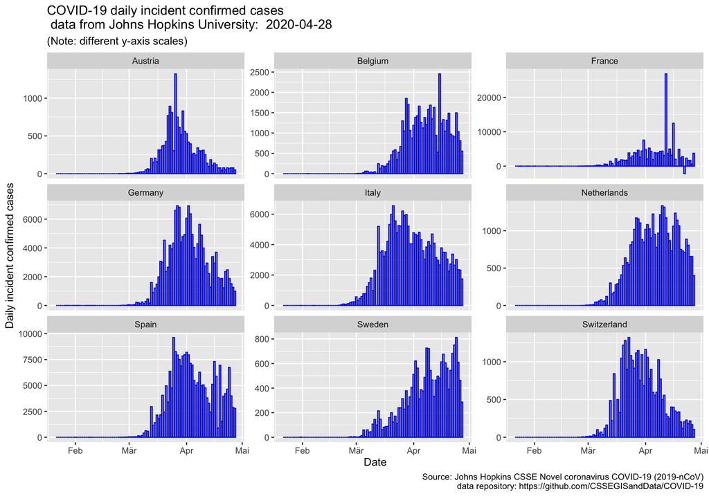

```r
title<-paste("COVID-19 daily incident confirmed cases\n data from Johns Hopkins University: ", dateDownloaded)
caption<-"Source: Johns Hopkins CSSE Novel coronavirus COVID-19 (2019-nCoV)\n data repository: https://github.com/CSSEGISandData/COVID-19"

ggplot(confirmedCasesSelected, aes(x = Date, y = incident_cases))+
  geom_col(color="blue", alpha=0.5)+
  #geom_line(color="blue",alpha=0.4, size=.3) +
  #geom_point(color="blue", alpha=0.5, size=2)+
  facet_wrap(country_region ~ ., scale = "free_y")+
  labs(y = "Daily incident confirmed cases", title = title,
       subtitle = "(Note: different y-axis scales)", caption = caption)+
  theme(legend.position = "none", legend.title = element_blank())
```

### Doubling Times

#### (Time it requires the amount of confirmed cases doubles)

The following plot shows developments of doubling times for various countries in europe. Increasing doubling times meaning a significant slowing down of the spreading of disease and must be considered as a result of social distancing and quaratine measures. There is no other measure as e.g. vaccination at this time. Also the exponential growth is not slowed down by the increasing amount of already recovered people. This effect may play a role when >10%…20%…30% of the population have become immune.

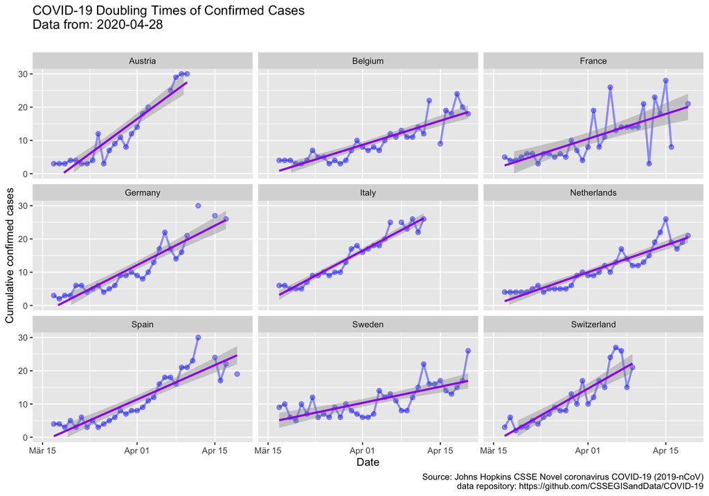

```r
title<-paste("COVID-19 Doubling Times of Confirmed Cases \nData from:", dateDownloaded)
caption<-"Source: Johns Hopkins CSSE Novel coronavirus COVID-19 (2019-nCoV)\n data repository: https://github.com/CSSEGISandData/COVID-19"

ggplot(confirmedCasesSelected%>%filter(Date>="2020-03-17"), aes(x = Date, y = T2))+
  geom_line(color="blue", alpha=0.4, cex=1) +
  geom_point(color="blue", alpha=0.4, cex=2)+
  geom_smooth(data=confirmedCasesSelected%>%filter(Date>="2020-03-17"), method = "lm",formula =y ~x, col="purple")+
  facet_wrap(country_region ~ .)+
  labs(y = "Cumulative confirmed cases", title = title,
       subtitle = "", caption = caption) +
  xlim(c(as.Date('2020-03-15 00:00:00', format = "%Y-%m-%d %H:%M:%S"),
         as.Date('2020-04-20 00:00:00', format = "%Y-%m-%d %H:%M:%S")))+
  ylim(c(0,30))+
  theme(legend.position = "none", legend.title = element_blank())
```

##### Doubling time beginning of March

```r
#Beginning of March
for(i in seq_along(countries)){
fitdata<-filter(confirmedCasesSelected,country_region == countries[i], Date >= "2020-03-01", Date <= "2020-03-15")%>%
  mutate(logCases=log(cumulative_cases))
model<-lm(logCases ~ Date, data = fitdata)
print(paste(countries[i], ": " ,round(log(2)/coef(model)[2],1), "days"))
}
```

```
## [1] "Italy :  3.6 days"
## [1] "Germany :  2.6 days"
## [1] "Switzerland :  2.4 days"
## [1] "Spain :  2.1 days"
## [1] "France :  2.6 days"
## [1] "Netherlands :  2.1 days"
## [1] "Sweden :  2.1 days"
## [1] "Austria :  2.3 days"
## [1] "Belgium :  1.8 days"
```

```r
for(i in seq_along(countries)){
  fitdata<-filter(confirmedCasesSelected,country_region == countries[i], Date >= "2020-03-16", Date <= dateDownloaded)%>%
    mutate(logCases=log(cumulative_cases))
  model<-lm(logCases ~ Date, data = fitdata)
  print(paste(countries[i], ": " ,round(log(2)/coef(model)[2],1), "days"))
}
```

```
## [1] "Italy :  17 days"
## [1] "Germany :  11.2 days"
## [1] "Switzerland :  14 days"
## [1] "Spain :  10.5 days"
## [1] "France :  9.3 days"
## [1] "Netherlands :  9.7 days"
## [1] "Sweden :  10 days"
## [1] "Austria :  13.7 days"
## [1] "Belgium :  8.1 days"
```